# Workshop 10 - Data Viz 3

Elisabeth Busch-Nentwich

## 1. Introduction

After the last two workshops you should have a good range of tricks up your sleeve for making graphs and making them look pretty. So for this last data viz workshop we’re going to spend a bit more time thinking about how to identify a good story in your data, and then how to make your data tell that story.

Load in these three libraries, you’re going to need them:

```r
library(tidyverse)
library(RColorBrewer)
library(patchwork)
```

## 2. Axes

Today we’ll be looking at two properly large datasets. I have downloaded and cleaned for you data on worldwide measles cases and vaccination rates from the [World Health Organization](https://immunizationdata.who.int/). Let’s read in the files:

```r
measles <- read.table("measles_cases_clean.txt", header = T, sep = "\t")
vacc_rates <- read.table("measles_vaccination_clean.txt", header = T, sep = "\t")
```

**Have a look at the two dataframes. What are the variables? Which years are covered? You may have to google what some of the variables mean.**

Let’s start exploring the data. How have cases developed over the years in the United Kingdom?

**Reproduce the following plot**.

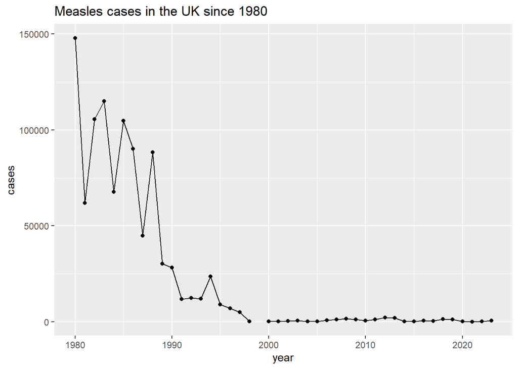

### Log scales

Well, that looks great! Cases have dropped a lot. But how low? It’s hard to tell. This is a problem you’ll encounter a lot; a y-axis with extremely large ranges which cannot easily be shown on the same scale. One answer to this is to use a logarithmic scale - instead of scaling linearly, this means each point up the y axis will be a factor of the one before (e.g. 10, 100, 1000…).

**Look through the available y axis scales and replace the default scale so your plot looks like this:**

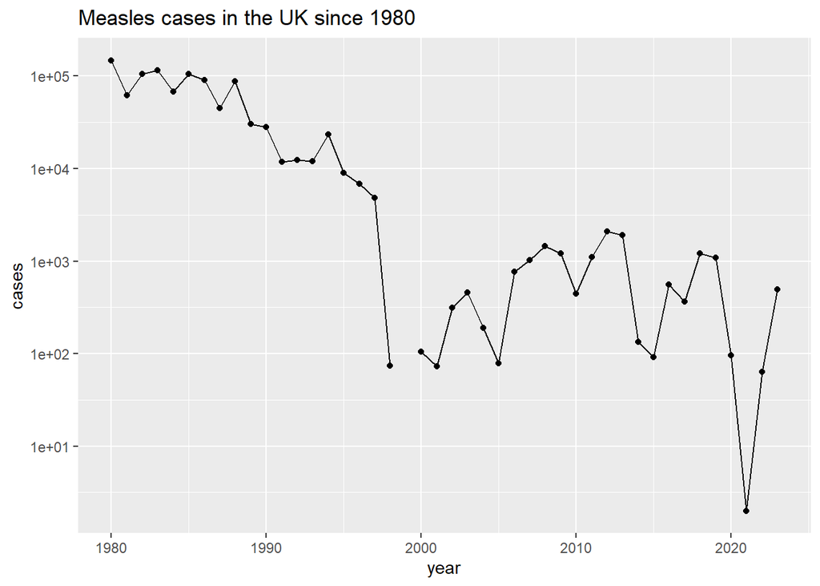

### Breaks

The scientific notation of the y-axis labels is hard to read.

**Have a look at the documentation and edit the breaks and labels, so that it looks like this:**

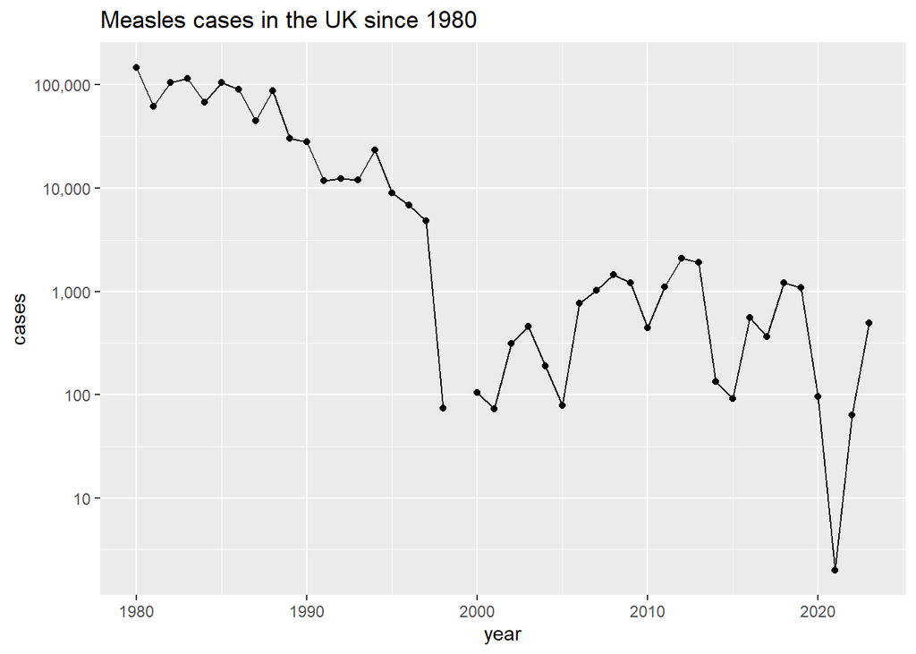

We can now see that cases dropped sharply, but there are still quite a lot of cases each year in the UK (NB: Any idea why so few in 2021?). Could this sustained level have something to do with vaccination coverage? Let’s have a quick look. We will use the vacc_rates dataframe and show the coverage according to WHO/UNICEF estimates (coverage_category == “WUENIC”). We’ll look at first and second vaccine dose.

**Produce the plot below by filtering the vaccination data for the United Kingdom and the correct coverage category.**

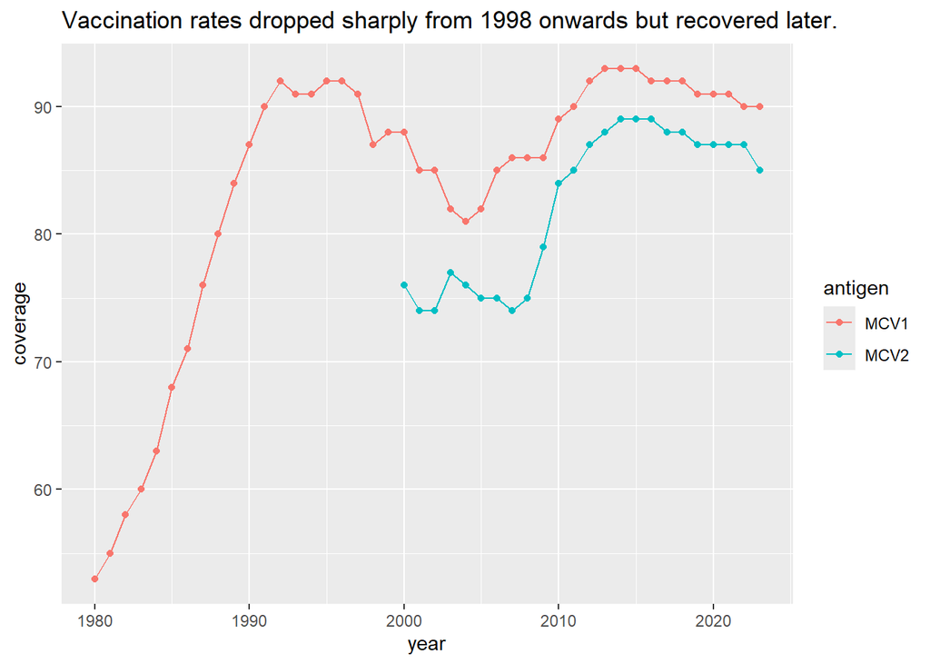

There is clearly a drop in vaccination rates in the late 1990s. It follows a publication in 1998 of a fraudulent paper on a link between autism and the MMR vaccine by the disgraced physician Andrew Wakefield. Luckily vaccination rates recovered after his claims were roundly debunked, but there is still room for improvement as we can see by the sustained cases.

How about global trends? Plotting cases for ~200 individual countries would be tedious. Can we look at cases per continent? This is where summary statistics are very useful.

## 3. Summary Tables

We can produce summary tables from a larger dataframe by grouping rows together and producing summary statistics for each group.

### Group By / Summarise

Let’s start by looking at yearly cases worldwide. To do this we need to *group* our data by year and then *summarise* our data by adding up the cases for each year.

It will not shock you to learn that the required functions are called `group_by()` and `summarise()`. Go take a look at their help files now…

If you run the first of these, `group_by`, the output looks *almost* the same, but this time the table has added an underlying flag to say that it can be grouped by year.

```r
measles %>%
  group_by(year)
```

```
## # A tibble: 8,360 × 4
## # Groups:   year [44]
##    entity       year cases continent
##    <chr>       <int> <int> <chr>
##  1 Afghanistan  2023  2792 Asia
##  2 Afghanistan  2022  5166 Asia
##  3 Afghanistan  2021  2900 Asia
##  4 Afghanistan  2020   640 Asia
##  5 Afghanistan  2019   353 Asia
##  6 Afghanistan  2018  2012 Asia
##  7 Afghanistan  2017  1511 Asia
##  8 Afghanistan  2016   638 Asia
##  9 Afghanistan  2015  1154 Asia
## 10 Afghanistan  2014   492 Asia
## # ℹ 8,350 more rows
```

It is when you add a summarize function (btw, American and British spelling both work) to this that an operation such as ‘sum’ can be applied to those groups.

Let’s see this in action. Group by the year and sum up the cases as follows:

```r
world_cases <- measles %>%
  drop_na() %>%
  group_by(year) %>%
  summarise(total = sum(cases))
```

Side note: Above we have to remove NAs first, otherwise lots of our sums will turn NA (try it out if you like). This is a good demonstration of the crucial difference between NA and a value of 0. If we add NA to a sum, the sum turns NA, because NA is not 0, but “dunno”. If you add an unknown quantity to a sum, the total sum is now unknown!

**Have a look at the data frame you have just created. Now plot the total for each year with ggplot like so:**

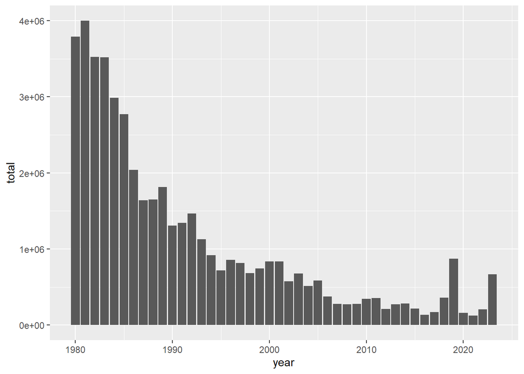

We can see that cases are going down world-wide, but we have pronounced peaks in 2019 and 2023. Is that a world-wide trend or something that is happening in one particular place?

**Produce another summary table called ‘continent_cases’ that groups by ‘continent’ and ‘year’. Then produce a bar chart where each continent is a different colour like below.**

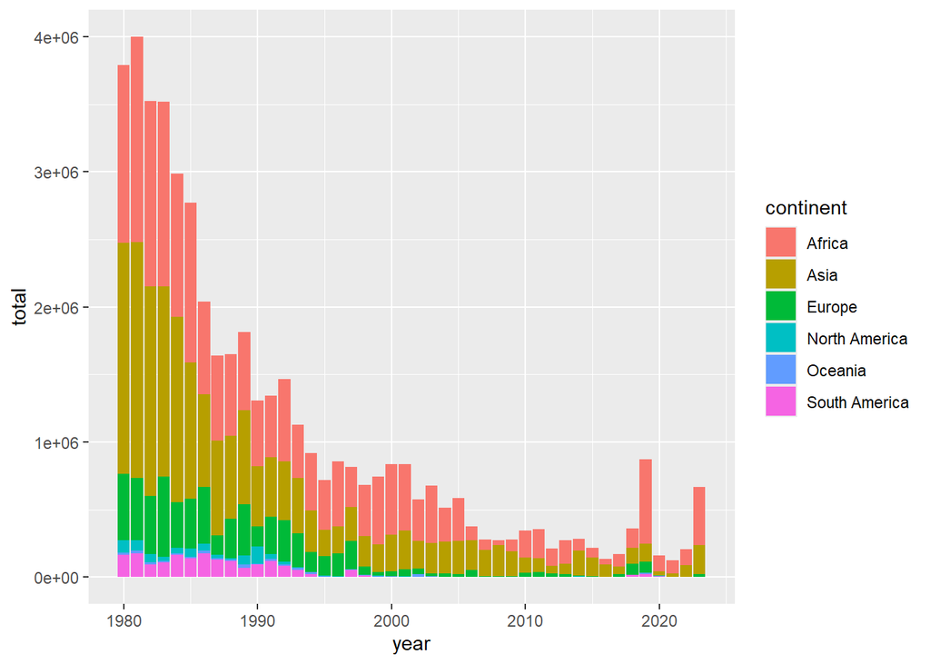

Now we can see that the peaks are largely driven by cases in Africa, but we don’t know which countries. Heatmaps are an excellent way to look at the interaction of three variables - particularly if we’re looking at occurrence data like we are here, and where we have lots of values for one variable (country).

## 4. Heatmaps

There are a few ways to do this in R and ggplot, but we’re going to use `geom_raster()`.

**This time use the measles dataframe directly and filter for Africa.**

**Your plot should look like this (the grey areas are NA, which is fine):**

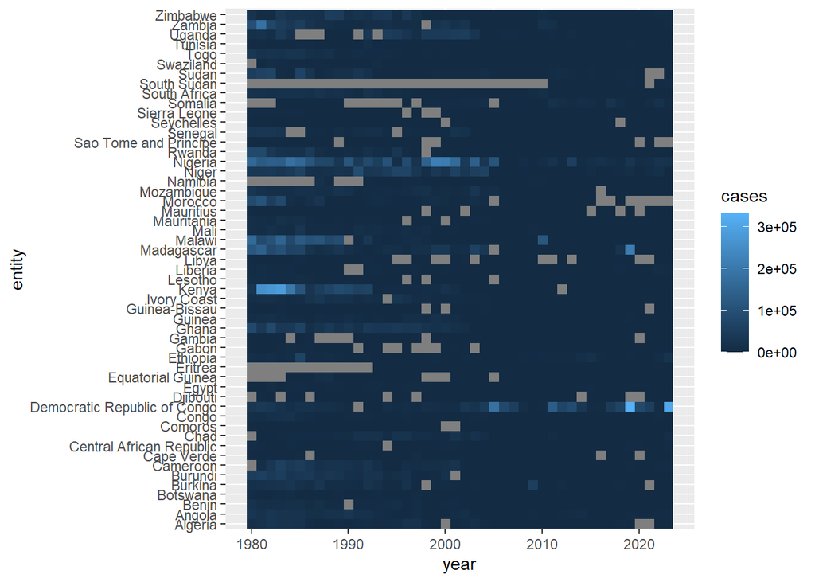

From the heatmap we can see that the two peaks are largely driven by outbreaks in the DRC.

This isn’t by any means a publication quality figure, but it is starting to show you some of the patterns that are present in this dataset.

This is often the first step in your exploratory data analysis - the rapid plots you will put together to see what shape your data is in and what further analyses you might want to focus on.

## 5. Finding a Story to Tell

Now let’s continue this exploratory analysis by looking at case counts in more detail. We already know that DRC is one of the main contributors to the 2019 peak. Which other countries have had lots of cases in that year?

```r
# Pull out countries with the ten highest case numbers in 2019

high_countries <- measles %>% filter(!is.na(cases) & year == 2019 ) %>%
  arrange(cases) %>%
  tail(n = 10L) %>%
  pull(entity)

# Make data subset of the ten countries with the most cases in 2019
high_measles_2019 <- measles %>% filter(entity %in% high_countries)

# Make countries a factor in order of cases, highest first
high_measles_2019$entity <- factor(high_measles_2019$entity, levels = rev(high_countries))
```

Let’s visualise these countries with the overall cases as well.

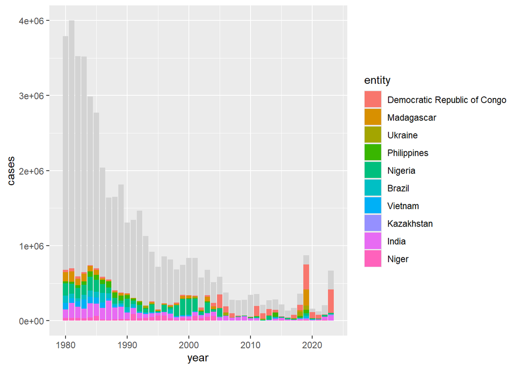

```r
measles %>% filter(!is.na(cases)) %>%
  ggplot(aes(x=year, y = cases)) +
  geom_col(fill = "lightgrey") +
  geom_col(data = filter(high_measles_2019, !is.na(cases)),
           aes(fill = entity))
```

It’s still quite hard to see how much those countries have contributed to our peaks of interest.

**Change the code above, so that it only shows the years 2010-2023.**

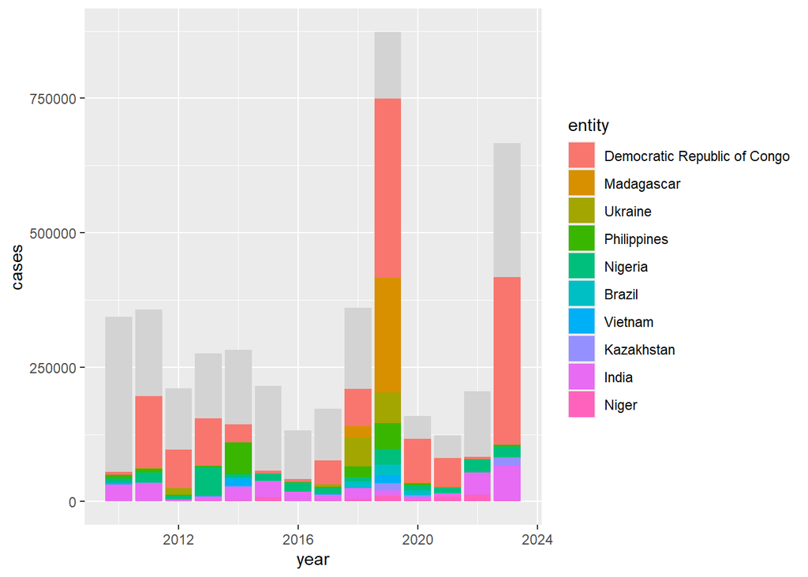

It turns out that the majority of cases in 2019 have come from just two countries: DRC and Madagascar. Let’s now turn our attention to vaccination coverage. How do vaccination rates compare across the globe?

**Reproduce the following plot using the WHO regions and WHO/UNICEF coverage estimates (coverage_category == “WUENIC”).**

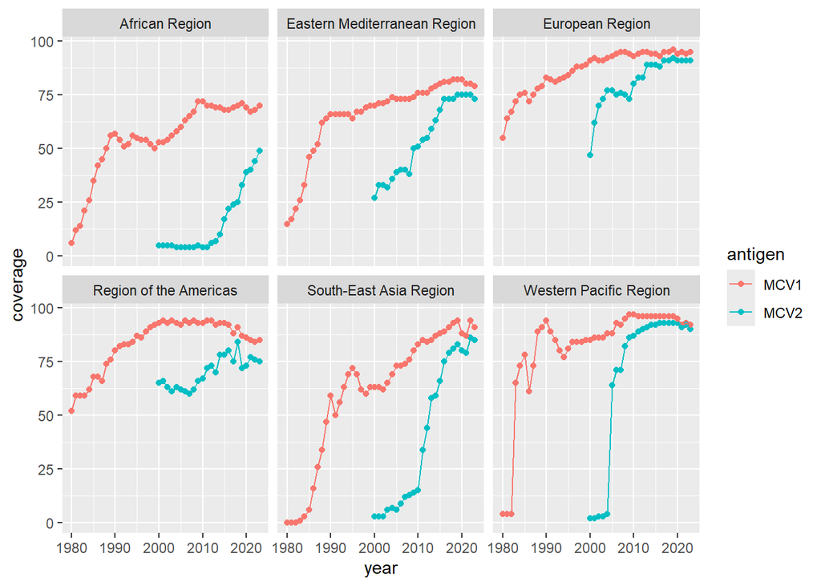

It is clear that the African region does not have the same level of vaccination coverage as high-income regions such as Europe. But how do DRC and Madagascar compare to the overall African region estimates?

**Modify your code above to compare DRC and Madagascar with the African and European Regions.**

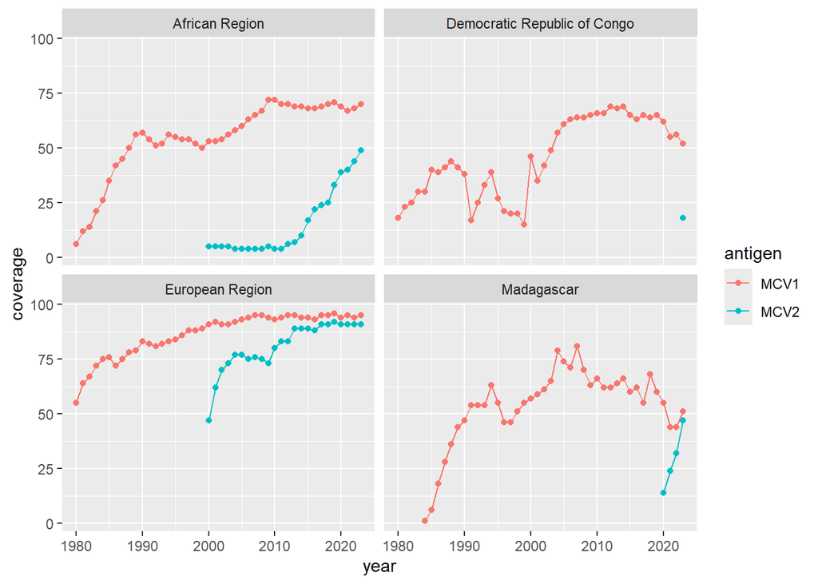

## 6. The big challenge

OK, so now we have a couple of stories to tell with this data: Measles cases have dropped sharply world-wide since the 1980s, but outbreaks occur due to vaccine access inequalities and vaccine hesitancy.This is a first glance at the data, and there is a lot more to explore. For example, there are different types of vaccination coverage data. How do WHO estimates and administration data differ across countries?

#### Putting your plots together.

Have a think about which aspects we have covered you would like to show. Not everything will fit into one graph!

#### Tips:

- you can change the size of legend units in theme() with legend.key.size
- check out plot_layout(guides=“collect”) and guide_area() to see how to put your guides all in the same place

**The end result could look like these examples:**

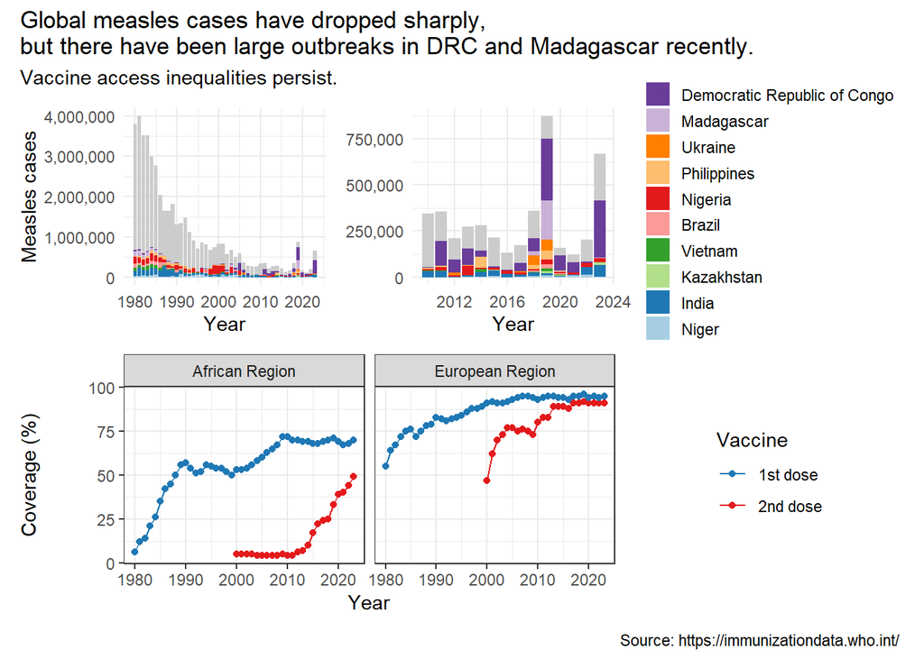

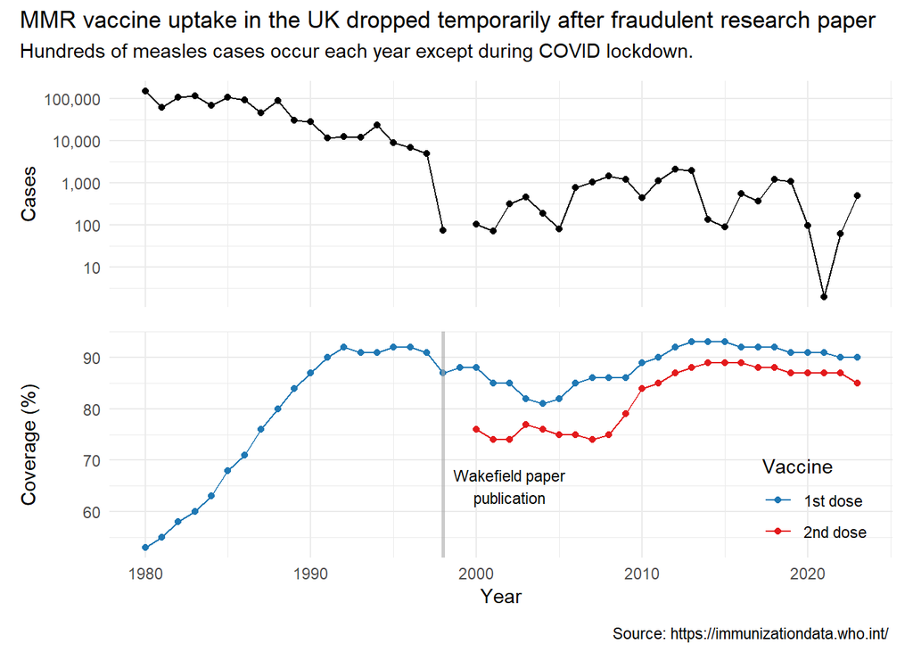